# Build your own Pytorch - 1: Computation graphs

The goal of this tutorial is provide a minimal self-contained implementation of automatic differentation. If you are developing machine learning algorithms or applications, you have definitely used PyTorch, TensorFlow, or JAX before. These are all examples of **automatic differentation (AD)** software. AD software is the backbone for AI algorithms since the advent of deep learning since training deep neural networks requires to compute gradients over the network via backpropagation. If you want to learn more about the fundamental principles in the design of such software, this tutorial is for you. It is split into 3 sections:

1. **Computation graphs**: we will learn how to build computation graphs, the fundamental data structure for AD. This is what this tutorial is going to focus on.
2. **Automatic differentation**: we are implementing the backpropagation algorithm on computation graphs - the core of an AD framework.
3. **In action**: we are using our framework to train a neural network on the MNIST dataset.

**Acknowledgement:** I took inspiration from [Mostafa Samir's](https://mostafa-samir.github.io/) tutorial on backpropagation and wanna thank him for letting me re-using parts of his code.

**Note: AD and differentiable programming.** AD software is basically a programming language for **so-called differentiable programming**. A program on a high level is basically an algorithm that converts an input to an output depending on certain parameters $\theta$: $$\text{Input}\to \text{Algorithm}(\theta)\to\text{Output}\to \text{Performance/Loss}$$ e.g. for a neural network, $\theta$ are the weights of that neural network. The key to *differentiable* programming is that we can compute the derivative with respect to $\theta$: $$ \frac{d}{d\theta}\text{Loss}=\frac{d}{d\theta}\text{Algorithm}(\theta)$$ and therefore, we can optimize the program via gradient descent: $$\theta_{t+1}=\theta_t-\lambda \frac{d}{d\theta}\text{Loss}$$ Therefore, the key to applying this paradigm is to be able to **differentiate any program**, i.e. to compute gradients. This is what we are going to learn in this tutorial.

```python
#!pip install pydot-ng
#!pip install graphviz
```

```python
import numpy as np
from collections import deque
import numpy as np
from heapq import heapify, heappush, heappop
import networkx as nx
from matplotlib import rc
import matplotlib.pyplot as plt
#!pip install pydot
#!pip install graphviz
```

## 1. The nodes in a computation graph

Computation graphs are directed graphs that describe the flow of computation of a program from input to output. In a computation graph, there are 2 types of nodes:

1. **Root nodes**: these have no parent nodes and no input edges. **Leaf nodes are created explicitly at the start of the program by specifying their value**. They can be either

   A. Constant (`ConstantNode`): the operational value of that node cannot be modified.

   B. Variable (`VariableNode`): the operational value of that node can be changed.

   (This distinction only becomes relevant later in the context of automatic differentation.)
2. **Non-root nodes**: these have parent nodes/input edges. These nodes are also called **operational nodes** (`OperationalNode`).The value of an operational nodes is determined the values of its input nodes.

### 1.1. Abstract base class for a node and Operational Node

We implement a node in a computation graph as an numpy array with an additional functionality: **if we perform an arithmetic operation with that node (`+,-,*,` etc.), we create a new `OperationalNode` that saves the parents (i.e. input) nodes**. This functionality is summarized in the `_nodify` function. This allows us to dynamically create a computation graph.

```python
class Node(np.ndarray):

    total_nodes_count = 0

    def __new__(subtype, shape,
                dtype=float,
                buffer=None,
                offset=0,
                strides=None,
                order=None):
        """
        craetes a new object that wraps an numpy.ndarray into a structure that
        represents a node in a computational graph
        """

        newobj = np.ndarray.__new__(
            subtype, shape, dtype,
            buffer, offset, strides,
            order
        )

        return newobj

    def _nodify(self, method_name, other, opname, self_first=True):
        """
        augments the operation of given arithmetic super method
        by creating and returning an OperationalNode for the operation

        Parameters:
        ----------
        method_name: String
            the name of the super method to be augmented
        other: Node | np.ndarray | Number
            the other operand to the operation
        opname: String
            the name of OperationalNode
        self_first: Boolean
            a flag indicating if self is the 1st operand in non commutative ops

        Returns: OperationalNode
        """
        if not isinstance(other, Node):
            other = ConstantNode.create_using(other)
        opvalue = getattr(np.ndarray, method_name)(self, other)

        return OperationalNode.create_using(opvalue, opname,
            self if self_first else other,
            other if self_first else self
        )


    def __add__(self, other):
        return self._nodify('__add__', other, 'add')

    def __radd__(self, other):
        return self._nodify('__radd__', other, 'add')

    def __sub__(self, other):
        return self._nodify('__sub__', other, 'sub')

    def __rsub__(self, other):
        return self._nodify('__rsub__', other, 'sub', False)

    def __mul__(self, other):
        return self._nodify('__mul__', other, 'mul')

    def __rmul__(self, other):
        return self._nodify('__rmul__', other, 'mul')

    def __div__(self, other):
        return self._nodify('__div__', other, 'div')

    def __rdiv__(self, other):
        return self._nodify('__rdiv__', other, 'div', False)

    def __truediv__(self, other):
        return self._nodify('__truediv__', other, 'div')

    def __rtruediv__(self, other):
        return self._nodify('__rtruediv__', other, 'div', False)

    def __pow__(self, other):
        return self._nodify('__pow__', other, 'pow')

    def __rpow__(self, other):
        return self._nodify('__rpow__', other, 'pow', False)

    @property
    def T(self):
        """
        augments numpy's T attribute by creating a node for the operation
        """
        opvalue = np.transpose(self)
        return OperationalNode.create_using(opvalue, 'transpose', self)

class OperationalNode(Node):

    # a static attribute to count for unnamed nodes
    nodes_counter = {}

    @staticmethod
    def create_using(opresult, opname, operand_a, operand_b=None, name=None):
        """
        craetes an graph node representing an operation

        Parameters:
        ----------
        opresult: np.ndarray
            the result of the operation
        opname: String
            the name of the operation
        operand_a: Node
            the first operand to the operation
        operand_b: Node
            the second operand to the operation if any
        name: String
            the name of the node

        Returns: OperationalNode
        """

        obj = OperationalNode(
            strides=opresult.strides,
            shape=opresult.shape,
            dtype=opresult.dtype,
            buffer=np.copy(opresult)
        )

        obj.opname = opname
        obj.operand_a = operand_a
        obj.operand_b = operand_b

        if name is not None:
            obj.name = name
        else:
            if opname not in OperationalNode.nodes_counter:
                OperationalNode.nodes_counter[opname] = 0

            node_id = OperationalNode.nodes_counter[opname]
            OperationalNode.nodes_counter[opname] += 1
            obj.name = "%s_%d" % (opname, node_id)

        obj.node_order = Node.total_nodes_count
        Node.total_nodes_count += 1

        return obj
```

### 1.2. Variable and Constant Node

These nodes are simple: basically, create numpy arrays with the specified values and give each node a unique name.

```python
class ConstantNode(Node):

    # a static attribute to count the unnamed instances
    count = 0

    @staticmethod
    def create_using(val, name=None):
        """
        creates a graph node representing a constant

        Parameters:
        ----------
        val: np.ndarray | Number
         the value of the constant
        name: String
         the node's name
        """
        if not isinstance(val, np.ndarray):
            val = np.array(val, dtype=float)

        obj = ConstantNode(
            strides=val.strides,
            shape=val.shape,
            dtype=val.dtype,
            buffer=val
        )
        if name is not None:
            obj.name = name
        else:
            obj.name = "const_%d" % (ConstantNode.count)
            ConstantNode.count += 1

        obj.node_order = Node.total_nodes_count
        Node.total_nodes_count += 1

        return obj


class VariableNode(Node):

    # a static attribute to count the unnamed instances
    count = 0

    @staticmethod
    def create_using(val, name=None):
        """
        creates a graph node representing a variable

        Parameters:
        ----------
        val: np.ndarray | Number
            the value of the constant
        name: String
            the node's name
        """
        if not isinstance(val, np.ndarray):
            val = np.array(val, dtype=float)

        obj = VariableNode(
            strides=val.strides,
            shape=val.shape,
            dtype=val.dtype,
            buffer=val
        )
        if name is not None:
            obj.name = name
        else:
            obj.name = "_%d" % (VariableNode.count)
            VariableNode.count += 1

        obj.node_order = Node.total_nodes_count
        Node.total_nodes_count += 1

        return obj
```

An example usage could like as follows:

```python
node_1 = VariableNode.create_using([2,-3,4])
node_2 = ConstantNode.create_using([1,2,4])
print(node_1)
print(node_2)
```

```
[ 2. -3.  4.]
[1. 2. 4.]
```

### 1.3. Arithmetic Operations with Nodes

Operational nodes are like the variable and constant nodes but with an additional functionality: we are saving what the parent nodes are that gave the operational nodes their value.

```python
sum_node_1_node_2 = node_1 + node_2
sum_node_1_node_2
```

```
OperationalNode([ 3., -1.,  8.])
```

```python
print("Operand A for sum: ", sum_node_1_node_2.operand_a)
print("Operand B for sum: ", sum_node_1_node_2.operand_b)
```

```
Operand A for sum:  [ 2. -3.  4.]
Operand B for sum:  [1. 2. 4.]
```

## 2. Node mathematics: `exp,sin,etc.`

Beyond having defined mathematical operation between arrays, we also want to define mathematical operations on arrays.

These functions are implemented all similarly. They execute the numpy operation and add an `OperationalNode` with a single parent node (for `exp,log,sin,cos,squeeze,reshape,etc.`) or two parent nodes for (`node_dot,etc.`):

```python
def sum(array, axis=None, keepdims=False, name=None):
    """
    defines a node in the computational graph representing a sum operation

    Parameters:
    ----------
    array: Node | ndarray | number
        the array to be summed
    axis: int
        the axis to perform the sum on
    keepdims: Boolean
        a flag to determine if the dimensions are kept
    name: String
        node's name in the graph
    """
    if not isinstance(array, Node):
        array = ConstantNode.create_using(array)
    opvalue = np.sum(array, axis=axis, keepdims=keepdims)

    opnode = OperationalNode.create_using(opvalue, 'sum', array, name=name)

    # save info for gradient computation
    opnode.axis = axis
    opnode.keepdims = keepdims
    opnode.with_keepdims = np.sum(array, axis=axis, keepdims=False)

    return opnode

def mean(array, axis=None, keepdims=False, name=None):
    """
    defines a node in the computational graph representing a mean operation

    Parameters:
    ----------
    array: Node | ndarray | number
        the array to be averaged
    axis: int
        the axis to perform the averaging on
    name: String
        node's name in the graph
    """
    if not isinstance(array, Node):
        array = ConstantNode.create_using(array)
    opvalue = np.mean(array, axis=axis, keepdims=keepdims)

    opnode = OperationalNode.create_using(opvalue, 'mean', array, name=name)

    # save info for gradient computation
    opnode.axis = axis
    opnode.keepdims = keepdims
    opnode.with_keepdims = np.mean(array, axis=axis, keepdims=False)

    return opnode


def exp(array, name=None):
    """
    defines a node in the computational graph representing an exp operation

    Parameters:
    ----------
    array: Node | ndarray | number
        the array to be exp-ed
    name: String
        node's name in the graph
    """
    if not isinstance(array, Node):
        array = ConstantNode.create_using(array)
    opvalue = np.exp(array)

    return OperationalNode.create_using(opvalue, 'exp', array, name=name)


def log(array, name=None):
    """
    defines a node in the computational graph representing an log operation

    Parameters:
    ----------
    array: Node | ndarray | number
        the array to be log-ed
    name: String
        node's name in the graph
    """
    if not isinstance(array, Node):
        array = ConstantNode.create_using(array)
    opvalue = np.log(array)

    return OperationalNode.create_using(opvalue, 'log', array, name=name)

def sin(array, name=None):
    """
    defines a node in the computational graph representing a sin operation

    Parameters:
    ----------
    array: Node | ndarray | number
        the array to be sin-ed
    name: String
        node's name in the graph
    """
    if not isinstance(array, Node):
        array = ConstantNode.create_using(array)
    opvalue = np.sin(array)

    return OperationalNode.create_using(opvalue, 'sin', array, name=name)

def cos(array, name=None):
    """
    defines a node in the computational graph representing a cos operation

    Parameters:
    ----------
    array: Node | ndarray | number
        the array to be sin-ed
    name: String
        node's name in the graph
    """
    if not isinstance(array, Node):
        array = ConstantNode.create_using(array)
    opvalue = np.cos(array)

    return OperationalNode.create_using(opvalue, 'cos', array, name=name)

def max(array, axis=None, keepdims=False, name=None):
    """
    defines a node in the computational graph representing a max operation

    Parameters:
    ----------
    array: Node | ndarray | number
        the array to be maxed out
    axis: int
        the axis to perform the max out on
    keepdims: Boolean
        a flag to determine if the dimensions are kept
    name: String
        node's name in the graph
    """
    if not isinstance(array, Node):
        array = ConstantNode.create_using(array)
    opvalue = np.max(array, axis=axis, keepdims=keepdims)
    opnode = OperationalNode.create_using(opvalue, 'max', array, name=name)

    # save info for gradient computation
    opnode.axis = axis
    opnode.keepdims = keepdims
    opnode.with_keepdims = np.max(array, axis=axis, keepdims=True)

    return opnode


def node_dot(array_a, array_b, name=None):
    """
    defines a node in the computational graph representing an array product op

    Parameters:
    ----------
    array_a: Node | ndarray | number
        the first operand to the product
    array_b: Node | ndarray | number
        the second operand to the product
    name: String
        the name of the node
    """
    assert len(array_a.shape) <=2 and len(array_b.shape)<=2,\
        "N dims for array must be <=2."

    if not isinstance(array_a, Node):
        array_a = ConstantNode.create_using(array_a)
    if not isinstance(array_b, Node):
        array_b = ConstantNode.create_using(array_b)
    opvalue = np.dot(array_a, array_b)

    return OperationalNode.create_using(opvalue, 'dot', array_a, array_b, name)


def where(condition, array_a, array_b, name=None):
    """
    defines a node in the computational graph representing a where selection
    operation

    Parameters:
    ----------
    condition: ndarray of Boolean
        the selection condition
    array_a: Node | ndarray | number
        the value to select from when the condition is True
    array_b: Node | ndarray | number
        the value to select from when the condition is False
    name: String
        the name of the node
    """
    if not isinstance(array_a, Node):
        nd_array_a = np.full_like(condition, array_a)
        array_a = ConstantNode.create_using(nd_array_a)
    if not isinstance(array_b, Node):
        nd_array_b = np.full_like(condition, array_b)
        array_b = ConstantNode.create_using(nd_array_b)

    assert array_a.shape == array_b.shape,\
        "Where operation did not have same shape. First reshape."

    opvalue = np.where(condition, array_a, array_b)
    opnode = OperationalNode.create_using(opvalue, 'where', array_a, array_b, name=name)
    opnode.condition = condition  # save condition for gradient computation

    return opnode

def softmax_cross_entropy(logits, labels, name=None):
    """
    defines a softmax-cross-entropy op as a primitive for numerical stability

    Parameters:
    ----------
    logits: Node| ndarray| Number
        the model's prediction
    labels:
        the true labels
    name: String
        node's name in the graph
    """
    if not isinstance(logits, Node):
        logits = ConstantNode.create_using(logits)
    if not isinstance(labels, Node):
        labels = ConstantNode.create_using(labels)

    assert len(logits.shape) == 2

    logits_max = np.max(logits, axis=1, keepdims=True)
    exp_op = np.exp(logits - logits_max)
    logits_softmax = exp_op / np.sum(exp_op, axis=1, keepdims=True)

    cross_entropy = -1 * np.sum((labels * np.log(logits_softmax + 1e-7))/logits_max.shape[0])

    opnode = OperationalNode.create_using(
        cross_entropy,
        'softmax_cross_entropy',
        logits,
        name=name
    )

    # save info for gradient calculations
    opnode.softmax_val = logits_softmax
    opnode.labels = labels

    return opnode

def reshape(array, new_shape, name=None):
    """
    defines a node in the computational graph representing a reshape operation

    Parameters:
    ----------
    array: Node| ndarray
        the array to be reshaped
    new_shape: iterable
        the new shape to put the array in
    name: String
        node's name in the graph
    """
    if not isinstance(array, Node):
        array = ConstantNode.create_using(array)
    opvalue = np.reshape(array, new_shape)

    return OperationalNode.create_using(opvalue, 'reshape', array, name=name)

def squeeze(array, axis=None, name=None):
    """
    defines a node in the computational graph representing a squeeze operation

    Parameters:
    ----------
    array: Node| ndarray
        the array to be squeezed
    axis: iterable
        the 1 axes to be squeezed out of the array
    name: String
        node's name in the graph
    """
    if not isinstance(array, Node):
        array = ConstantNode.create_using(array)
    opvalue = np.squeeze(array, axis=axis)

    return OperationalNode.create_using(opvalue, 'squeeze', array, name=name)
```

1. We can take `exp,log,sin,cos`:

```python
exp_node_1 = exp(node_1)
log_node_1 = log(node_1)
sin_node_1 = sin(node_1)
cos_node_1 = cos(node_1)
```

1. We can take `sum,mean` reducing the value of the node to a single float

```python
sum_node_1 = sum(node_1)
print("Node 1: ", node_1)
print("Sum node 1: ", sum_node_1)
assert sum_node_1.operand_b is None #The second operator should be none as it has only one input
sum_node_1.operand_a
```

```
Node 1:  [ 2. -3.  4.]
Sum node 1:  3.0
```

```
VariableNode([ 2., -3.,  4.])
```

1. We can reshape and squeeze

```python
reshape_node_1 = reshape(node_1,(1,3,1))
squeeze(reshape_node_1)
```

```
OperationalNode([ 2., -3.,  4.])
```

1. We can take the dot product

```python
dot_product = node_dot(node_1,node_2)
dot_product
```

```
OperationalNode(12.)
```

1. We can also perform operations like `max` or `where`:

```python
max_node_1 = max(node_1)
where(node_1>0,node_1,0) #this implements the ReLU function
```

```
OperationalNode([2., 0., 4.])
```

## 3. Building the computation graph

Note that we have never explicitly defined the computation graph. Rather, the graph is implicitly defined for each `OperationalNode` as we have save its parent nodes in `operand_a, operand_b`. We with that, we can perform a **dynamic construction of a computation graph** by going from a node backwards over their parents. The most famous example is `PyTorch` that creates computation graph on the fly. Originally, this was in contrast to `TensorFlow` that defined computation graph in a static fashion with the goal of achieving better computational efficiency. By now, TensorFlow also offers dynamic construction of computation graphs.

To construct a computation graph, we pick an `OperationalNode` (the leaf node in the computation graph) and then go backwards to each node's parents to create a computation graph until we terminate at `VariableNode`s or `ConstantNode`s. To do, we need to be able to track a hiearchy of nodes - we need a heap :)

### 3.1. Nodes Heap

Note that in the definition of a `Node` above, we included the value of a `total_nodes_count`. This gives a hierarchy of nodes in the order that the nodes have been created. We use a nodes heap that keeps track of the hierachy of nodes and let's us retrieve the element highest in the hierarchy:

```python
class NodesHeap:

    def __init__(self):
        """
        creates a node heap that returns the node of maximum order
        """

        self.nodes_heap = []
        heapify(self.nodes_heap)

    def push(self, node):
        """
        pushes a given node, along with its name, to the nodes_heap

        Parameters:
        ----------
        node: Node
            the node to be pushed
        """
        heappush(self.nodes_heap, (-node.node_order, node))

    def pop(self):
        """
        pops the front node from the nodes_heap, along with its name

        Returns: Node
        """

        return heappop(self.nodes_heap)[1]

    def __contains__(self, node):
        """
        implements the searching operator via `in` by searching in the names
        nodes_heap instead of the nodes themselves nodes_heap to capture unique nodes
        with exact numerical values

        Parameters:
        ----------
        node: Node
            the node to search for
        Returns: Boolean
        """
        return node.name in [node_it[1].name for node_it in self.nodes_heap]

    def __len__(self):
        """
        returns the length on any of the underlying deques

        Returns: int
        """
        return len(self.nodes_heap)
```

A small example:

```python
#Create 4 nodes
node_1 = VariableNode.create_using([2,-3,4])
node_2 = ConstantNode.create_using([1,2,4])
node_3 = ConstantNode.create_using([-1,2,4])
node_4 = node_1 + node_2

#Check nodes order:
print("Node 1 | Order = ", node_1.node_order)
print("Node 2 | Order = ", node_2.node_order)
print("Node 3 | Order = ", node_3.node_order)
print("Node 4 | Order = ", node_4.node_order)
print()

#Create nodes heap:
nodes_heap = NodesHeap()

#Add 4 nodes:
nodes_heap.push(node_4)
nodes_heap.push(node_3)
nodes_heap.push(node_2)
nodes_heap.push(node_1)

#Remove 4 nodes step by step:
print((nodes_heap.pop()==node_4).all())
print((nodes_heap.pop()==node_3).all())
print((nodes_heap.pop()==node_2).all())
print((nodes_heap.pop()==node_1).all())
```

```
Node 1 | Order =  14
Node 2 | Order =  15
Node 3 | Order =  16
Node 4 | Order =  17

True
True
True
True
```

### 3.2. Breadth-First Search

Next, we build a function that creates the computation graph explicitly from a leaf node of your choice using `NodesHeap`. The computation is as follows:

1. Initialize `NodesQueue` with selected leaf node $l$.
2. Initialize graph `G` with a single node $l$.
3. While `NodesQueue` not empty:\

   ```
   3.1 Pop node $n$ in `NodesQueue` with highest `node_order`.\
   3.2. If $n$ is `OperationalNode`, then add all parent nodes $a,b$ to `G` and add edges $a\to n,b\to n$ to `G`.
   ```

4. Return `G`

**Note:** It is important to note that the algorithm is terminating because a computation graph has no cycles: the `node_order` of a child nodes is higher than the `node_order` of its parents. So if $n_1\to n_2\to...\to n_m \to n_1$ is a cycle in $G$, then `node_order`($n_1$)$<$ `node_order`($n_2$)$<$...$<$ `node_order`($n_m$)$<$ `node_order`($n_1$). This is a contradiction...Therefore, $G$ can have no cycles and therefore, the breadth-first search will terminate.

```python
def build_and_visualize_graph(node, figsize=None):
    """
    visualizes the graph starting from the given node back to constant and
    variable nodes

    Parameters:
    ----------
    node: nodes.Node
        the root node to visualize its computational graph
    """

    G = nx.DiGraph(graph={'rankdir': 'LR'})

    #Add nodes_heap of nodes to traverse backwards
    nodes_heap = NodesHeap()

    #Color schemes for various nodes:
    color_dict = {'VariableNode': 'lightblue', 'ConstantNode': 'orange'}
    color = lambda n: color_dict[n.__class__.__name__] if n.__class__.__name__ in color_dict else '#d5a6f9'

    #Add root node:
    G.add_node(node.name, label=f"${node.name}$", color=color(node))

    #Push node, i.e. add it to the top
    nodes_heap.push(node)

    while nodes_heap:
        #Pop left-most node, i.e. the node that was first in the nodes_heap
        #(i.e. we do breadth first search)
        current = nodes_heap.pop()

        #Variable and constant nodes have not parents, ignore them and continue
        if isinstance(current, VariableNode) or isinstance(current, ConstantNode):
            continue

        #Get the most parent nodes:
        previous_nodes = sorted(
            filter(lambda n: n is not None, [current.operand_a, current.operand_b]),
            key=lambda n: n.name
        )

        #Add them to the graph and add them to the right of the nodes_heap:
        for prev_node in previous_nodes:
            if prev_node is not None:
                G.add_node(prev_node.name, label=f"${prev_node.name}$", color=color(prev_node))
                G.add_edge(prev_node.name, current.name)

                if prev_node not in nodes_heap:
                    nodes_heap.push(prev_node)

    nodes_colors = [_node[1]["color"] for _node in G.nodes(data=True)]
    nodes_labels = {_node[0]: _node[1]["label"] for _node in G.nodes(data=True)}
    edges_labels = {_edge: '$x$' for _edge in G.edges()}

    pos=nx.nx_pydot.pydot_layout(G,prog='dot')

    rc("mathtext", fontset='cm')
    plt.figure(figsize=figsize)

    nx.draw_networkx(G, pos, with_labels=False, arrows=True, node_color=nodes_colors, node_size=2000)
    nx.draw_networkx_labels(G, pos, labels=nodes_labels, font_size=15)

    return G
```

**Note that the dynamic construction implies that that the constructed graph will only be parts that are "ancestors" of that leaf node.** See the example below.

```python
#Squared sum:
power = ConstantNode.create_using(10)
squared_sum = sum_node_1_node_2**power

#Path 1 - cos:
cos_sum = cos(sum_node_1_node_2)

#Path 2 - mean after reshaping:
squared_sum_reshape = reshape(squared_sum,(1,3,1))
mean_result = mean(squared_sum_reshape)

G = build_and_visualize_graph(cos_sum)
G = build_and_visualize_graph(mean_result)
```

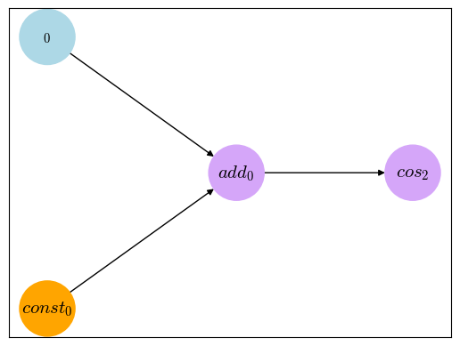

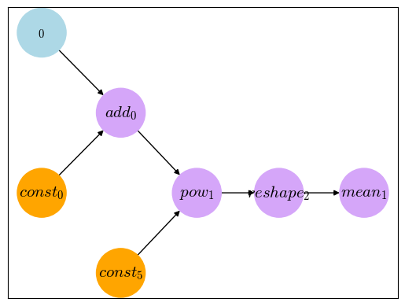

## Summary

We have create a functionality that allows us to dynamically create computation graphs with simple mathematical operations. Next, we need to use this functionality to compute gradients, i.e. to do backpropagation.